# 酒後計程車費的補貼成本估計

Chiahua.Wang

2018/1/28

## 結論

把結論寫在前面，是讓大家快點看到，節省時間。想知道原由和過程的可以再往後面看。

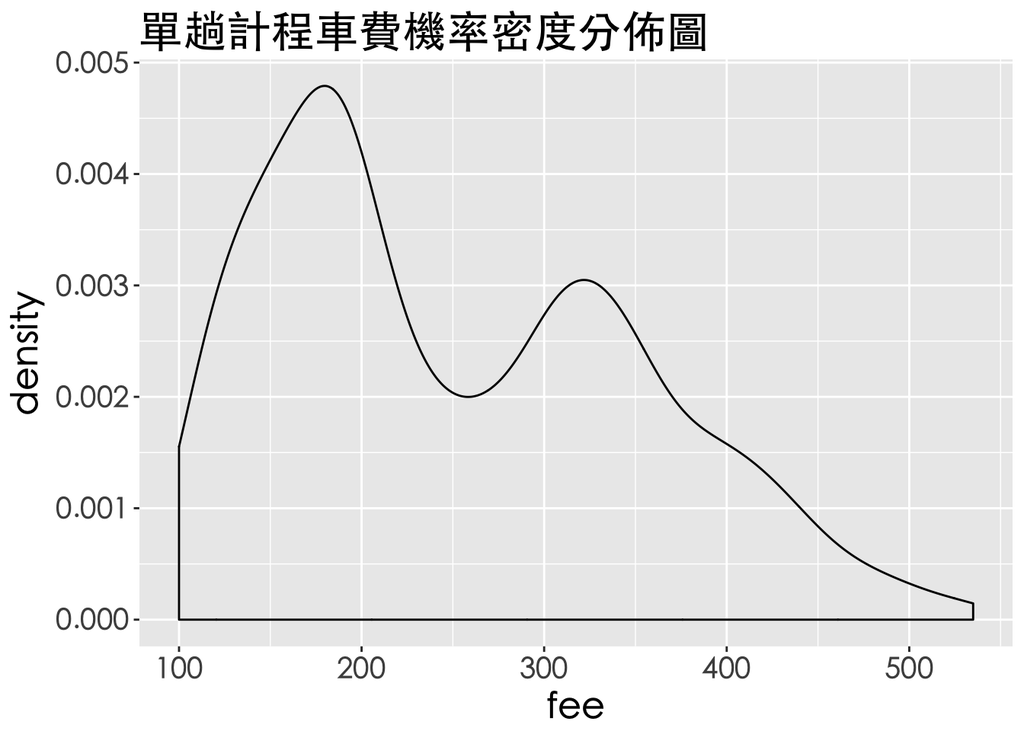

單趟的計程車費總額可能落在 130 到 400 之間。（90%信賴區間）

如果一天可能有 1 到 500 車次的話，單日及全年的計程車費可能範圍如下：

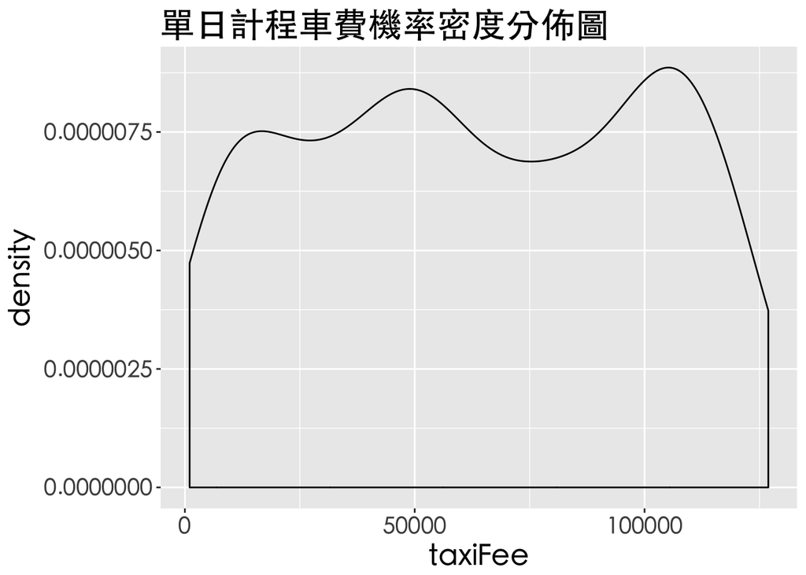

單日的計程車費總額可能落在 10392 到 113196 之間。（90%信賴區間）

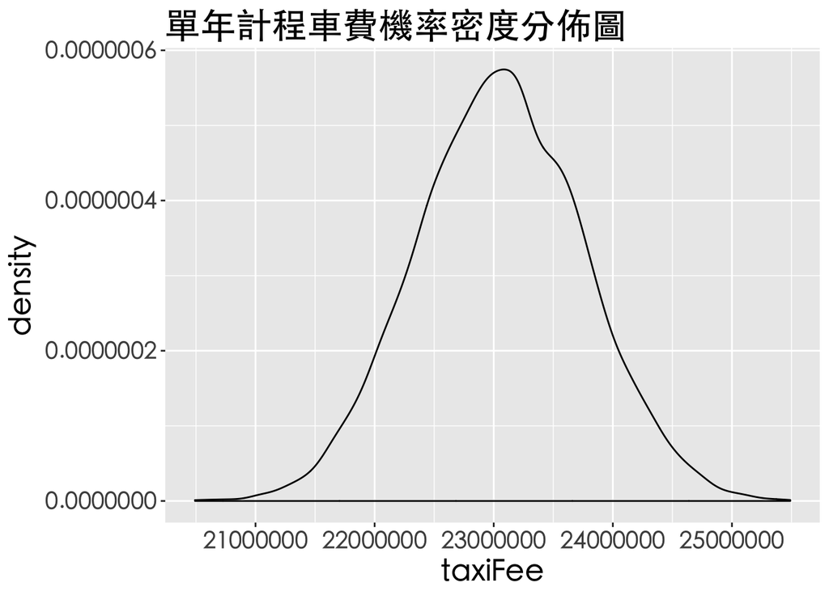

單年的計程車費總額可能落在 22151808.5 到 23946664.5 。（90%信賴區間）

## 關於這個專案

酒駕一直是個問題。facebook 的「關心金門者」在前些日子，由金門酒廠的高層提出了代駕或計程車費補貼等方式，以減少酒駕問題的討論方向。我覺得這樣的作法可以具體的改善酒駕問題，同時也反映了金門酒廠的社會責任態度，因此十分贊同這樣的討論。

但問題來了，以計程車費補貼的方式來說，該補貼多少呢？以及，這樣的補貼方式，金門酒廠面對的量體及成本又可能是多少呢？

因此我興起了念頭，開了這個 side project。

## 估計方式

原理很簡單，就是試著估計一年365天裡，每天可能會有幾趟酒後計程車，每趟可能開多遠，計程車費可能是多少錢。然後再加總起來，算一年的可能成本。

計程車開多遠的部分，先用 OpenStreetMap 取得餐廳坐標，再加上用 QGIS 建立金門隨機點坐標。接著利用餐廳的坐標及散布在全金門的隨機點坐標，隨機取兩點出來做為起、終點，然後用 Google Maps API 進行導航。如此一來，我們就取得了 2322 條導航路徑資料。從中取出直線距離(d)、行駛距離(m)和行駛時間(t)來計算計程車費。

以這樣的隨機路徑為樣本，再以隨機取樣的方式估計每天可能的補貼車次，再概算出全年可能的成本。

計程車費公式：

車資 = 100+round(ifelse((m-1000)<0,0,m-1000)/250,0)*5 夜間加乘車資 = 100+round(ifelse((m-800)<0,0,m-800)/200,0)*5

## 假設條件

因為我不知道金門的餐廳每天有多少客人（開多少桌）、喝幾瓶酒、每桌有喝酒的人有多少人。但這是很重要的資訊，因為不知道每天會有多少人喝酒，就無法估計可能會產生多少酒後搭乘計程車的需求。

做為替代，這裡使用隨機分配建立模型。如果有實際上的市場調查，概估就會更接近真值。

假設條件：每天可能有1 ~ 500 車次。以及兩點直線距離小於1公里時，不會叫車；也就是沒有短乘需求。雖然研究報告顯示，酒後走路危險性還比較高一點。

## 建立隨機路徑資料

過程可以直接看 After-Drink.R 。

## 資料探索

### 資料集

taxi： Google Maps API 的 2322 筆導航路徑結果。

taxi.trip：從 taxi 中取出的兩點間直線距離(d)、行駛距離(m)和行駛時間(t)，再計算出計程車費(fee)和夜間加乘後的計程車費(nigthfee)

taxi.est：365天的計程車費估計。cars是車次、taxiFee是車資。

taxi.est.y：全年計程車費估計。cars是全年累計車次、taxiFee是全年累計車資。建立方式在原始碼裡有。基本上是先隨機取得365筆單日車次，再依車次數取得隨機路徑，計算總計費率，然後重覆1萬次。

### 探索

首先是 2068 筆隨機路徑的模擬結果。

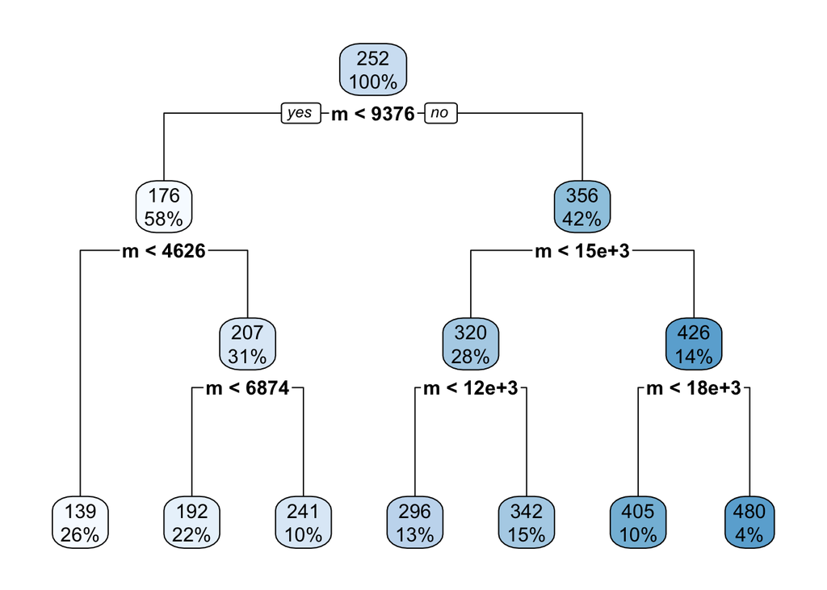

以決策樹演算法對行駛距離及車資進行分類，可以發現隨機行駛路徑中，約有 26% 的車次其實都在5公里的距離內（4626公尺），平均車次 139 元。7公里內多達 48% （6874公尺），平均車次可以概分為 139 元、192 元等兩類。平均車資會超過 405 元的大約只佔 14%。

假設以滿足 70% 的人為目標，12 公里以內大約佔 71%，平均車資分別為 139、192、241 和 296 元。固定車資補貼 100元後，則使用者平均負擔成本分別為 39 、92、141 和196元。金酒面臨的年成本可能在 8788380 到 9500600 之間。

若是採固定比例補貼，那麼金酒面臨的年成本可能性如下表：

| rate | lower | upper |
| --- | --- | --- |
| 0.10 | 2215181 | 2394666 |
| 0.15 | 3322771 | 3592000 |
| 0.20 | 4430362 | 4789333 |
| 0.25 | 5537952 | 5986666 |
| 0.30 | 6645543 | 7183999 |
| 0.35 | 7753133 | 8381333 |
| 0.40 | 8860723 | 9578666 |
| 0.45 | 9968314 | 10775999 |
| 0.50 | 11075904 | 11973332 |
| 0.55 | 12183495 | 13170665 |
| 0.60 | 13291085 | 14367999 |
| 0.65 | 14398676 | 15565332 |
| 0.70 | 15506266 | 16762665 |
| 0.75 | 16613856 | 17959998 |
| 0.80 | 17721447 | 19157332 |
| 0.85 | 18829037 | 20354665 |
| 0.90 | 19936628 | 21551998 |
| 0.95 | 21044218 | 22749331 |
| 1.00 | 22151808 | 23946664 |

補貼策略還有很多種。例如「固定比例+最小自付額」、「固定金額+最小自付額」等等方式都可以。但在擬定這樣的策略時，必需注意誘因強度以及預期成本，設法在兩者之間取得平衡；驗證方式又是另一個討論的議題了。

## 寫在最後

原本預計一個週末就要把這個小專案寫完，但最後還是寫寫停停的，一直到快過年了才寫個架構出來。資料探索原本還想寫更多，但我後來想想，如果能讓大家自己算，不是更好嗎？於是我打算寫個 shinyapps，設定好條件，讓大家自己設定自己的估計，然後看看自己的猜想所產生的成本會是多少。

寫出來後會再丟出來給大家玩。